# Introduction to Bayesian Statistics with R

## Average difference?

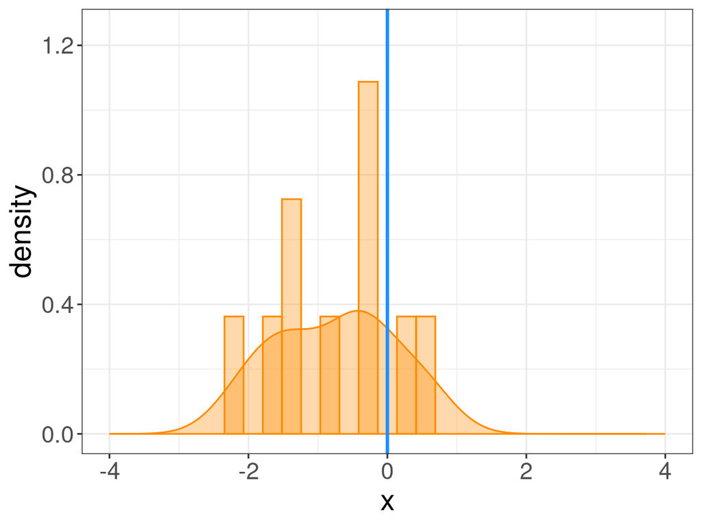

Question: is the mean 0?

## Average difference?

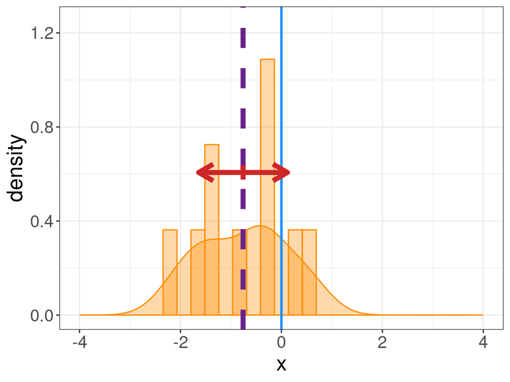

- display sample mean and sample standard deviation

## CLT recap

The sample mean

\[m = \frac{1}{N}\sum_{i=1}^{N}x_i\]

is a random variable

- mean estimate: \(\widehat{\mu_{m}} = \overline{x}\), which is \(m\)
- variance estimate: \(\widehat{\sigma_{m}^{2}} = \frac{s^2}{N}\), with \(s^2\) the sample variance
- standard error (standard deviation of the mean)

\[s_{m} = \frac{s}{\sqrt{N}}\]

- becomes Gaussian as \(N\to\infty\) (CLT)

## The normal distribution

Normally distributed \(X\)

- continuous state space:

\[X \in \mathbb{R}\]

- probability:

\[P(x<X\leq x+\mathrm{d}x) = f(x)\mathrm{d}x\] for infinitesimal \(\mathrm{d}x\)

- \(f(x)\) is the probability density

\[f(x) = \frac{1}{\sqrt{2\pi\sigma^2}}\mathrm{e}^{-\frac{(x-\mu)^2}{2\sigma^2}}\]

Parameters

- mean \(\mu\)
- variance \(\sigma^2\)

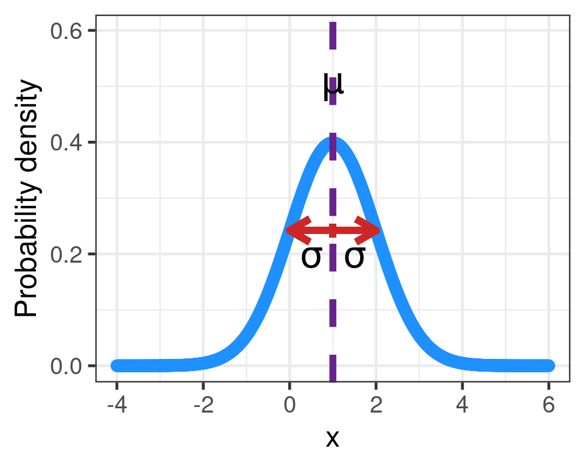

## Average difference?

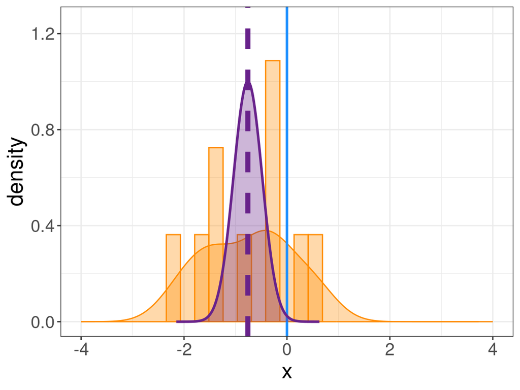

- Estimated Gaussian approximation to the distribution of the sample mean (unnormalised)

## Probability that the mean is 0?

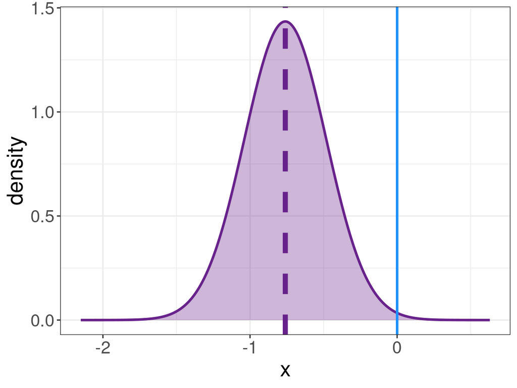

Question: with the Gaussian approximation, what is the probability the mean is 0?

Answer: 0

## \(p\)-values

Invert the thinking

- assume the true mean is 0

\[\mu_m=0\]

- \(z\) is Gaussian approximation to sample mean distribution with mean fixed to 0

\[z \sim \mathcal{N}(0,s_m^2)\]

## \(p\)-values

Invert the thinking

- assume the true mean is 0

\[\mu_m=0 \, , \qquad z \sim \mathcal{N}(0,s_m^2)\]

Question: how do we obtain a probability of observing a sample mean \(m\)?

Answer: we need to select a range of \(z\)

## \(p\)-values

Invert the thinking

- assume the true mean is 0

\[\mu_m=0 \, , \qquad z \sim \mathcal{N}(0,s_m^2)\]

Question: which range should we take?

Answer: more (or as) extreme values than \(\vert m\vert\)

## \(p\)-values

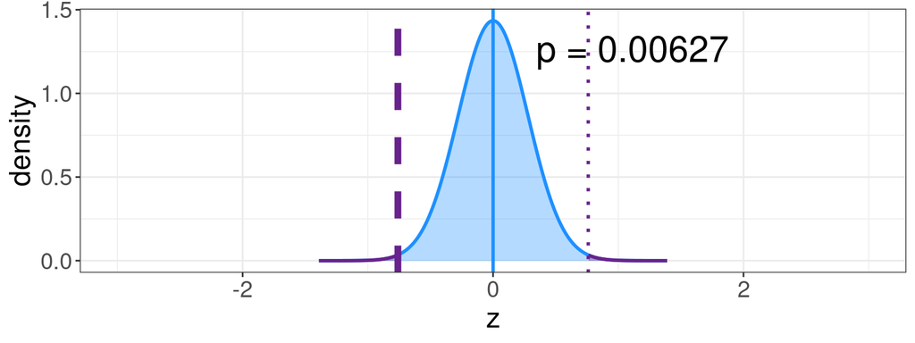

The \(p\)-value is the probability of observing a more extreme (or as extreme) sample mean

\[p = P(\vert z \vert \geq \vert m \vert) , \qquad z \sim \mathcal{N}(0,s_m^2)\]

- assuming the true mean is 0

Question: why take absolute values?

Answer: because the sample mean can be extreme in either direction

## Computing \(p\)-values

Define null hypothesis \(H_0\)

- that there is no effect
- mean \(\mu_0 = 0\)

Rescale sample mean to obtain \(t\)-statistic

\[t = \frac{m - \mu_0}{s_m} = \sqrt{N} \frac{m-\mu_0}{s}\]

Compute the distribution of \(t\) assuming \(H_0\)

- \(\mu_m=0\)

But the sample variance and standard error \(s_m\) is a random variable

- adds variance to \(t\)

Normal data leads to Student-\(t\) distribution

\[t \sim \mathcal{T}_{N-1}\]

## The Student-\(t\) distribution

Student-\(t\) distributed \(T\)

- continuous state space:

\[T \in \mathbb{R}\]

- probability:

\[P(t<T\leq t+\mathrm{d}t) = f(t)\mathrm{d}t\] for infinitessimal \(\mathrm{d}t\)

- \(f(t)\) is the probability density

\[f(t) = \frac{\Gamma\left(\frac{\nu+1}{2}\right)}{\sqrt{\pi\nu}\Gamma\left(\frac{\nu}{2}\right)}\left(1+\frac{t^2}{\nu}\right)^{-\frac{\nu+1}{2}}\]

Parameter

- degrees of freedom \(\nu>0\)

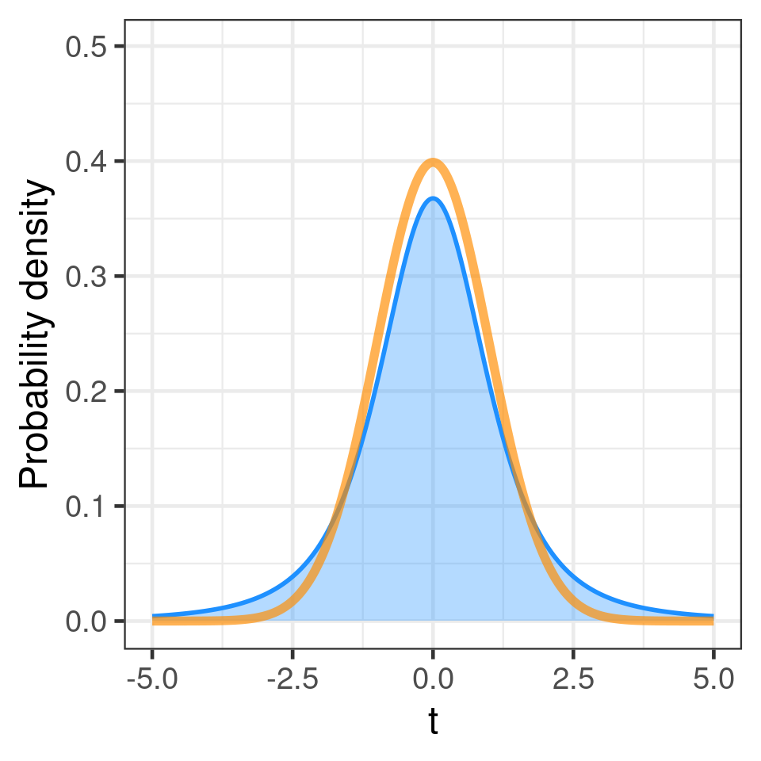

- Becomes Gaussian as \(\nu\to\infty\)

## Computing \(p\)-values

Define null hypothesis \(H_0\)

- that there is no effect
- mean \(\mu_0 = 0\)

Compute \(t\)-statistic

\[t = \frac{m - \mu_0}{s_m} = \sqrt{N} \frac{m-\mu_0}{s}\]

Follows Student-\(t\) distribution under the null

\[t_0 \sim \mathcal{T}_{N-1}\]

- if data is normally distributed

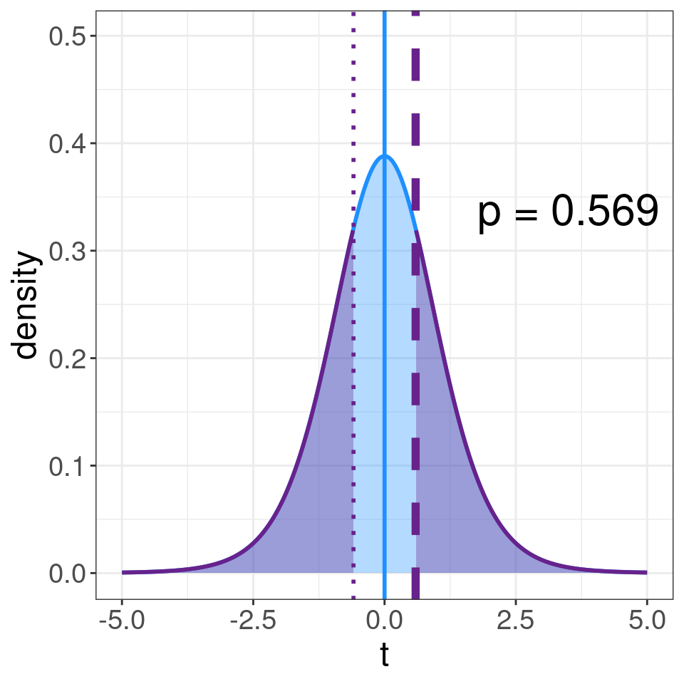

Question: is the mean 0?

Answer: no (it’s actually -0.25). We can see it is negative better with larger sample sizes.

## Computing in R

base R

With the t.test(…) function

```r
# Generate some Gaussian samples with mean -0.25
test_samples <- rnorm(50, mean = -0.25, sd = 1)
```

- test if the mean is 0

```r
# Run a t-test with null hypothesis of mean 0
t.test(test_samples)
```

```
##
##  One Sample t-test
##
## data:  test_samples
## t = -3.8539, df = 49, p-value = 0.0003385
## alternative hypothesis: true mean is not equal to 0
## 95 percent confidence interval:
##  -0.8379003 -0.2635547
## sample estimates:
##  mean of x
## -0.5507275
```

## Computing in R

base R

With the t.test(…) function

```r
# Generate some Gaussian samples with mean -0.25
test_samples <- rnorm(50, mean = -0.25, sd = 1)
```

- test if the mean is 0

```r
# extract the t-statistic
t.test(test_samples)$statistic
```

```
##         t
## -3.853876
```

```r
# extract the p-value
t.test(test_samples)$p.value
```

```
## [1] 0.0003385396
```

## Two sample \(t\)-test in R

base R

With the t.test(…) function

```r
# Generate some Gaussian samples with mean -0.25 and control with mean 0
test_samples <- rnorm(50, mean = -0.25, sd = 1)
control_samples <- rnorm(50, mean = 0, sd = 1)
```

- test for a difference in means

```r
# Run a two sample t-test with null hypothesis of equal means
t.test(test_samples, control_samples)
```

```
##
##  Welch Two Sample t-test
##
## data:  test_samples and control_samples
## t = -2.6511, df = 97.856, p-value = 0.009358
## alternative hypothesis: true difference in means is not equal to 0
## 95 percent confidence interval:
##  -0.9553229 -0.1373819
## sample estimates:
##    mean of x    mean of y
## -0.550727492 -0.004375063
```

## Two sample \(t\)-test in R

base R

With the t.test(…) function

```r
# Read in the swiss army data from file
swiss_army_df <- read.csv("./data/Zurich_data.csv")
# use the regression formulation
t.test(Height ~ Sex, swiss_army_df)
```

```
##
##  Welch Two Sample t-test
##
## data:  Height by Sex
## t = -29.278, df = 1152.2, p-value < 2.2e-16
## alternative hypothesis: true difference in means between group F and group M is not equal to 0
## 95 percent confidence interval:
##  -11.151169  -9.750496
## sample estimates:
## mean in group F mean in group M
##        161.7041        172.1550
```

- clear difference in mean heights, and large sample size

## Summary

\(p\)-values are a measure of surprise

- how unusual would the data be under the null?

For normal data the rescaled sample mean

- follows a Student \(t\)-distribution
- becomes more normal with larger sample sizes (CLT)

\(t\)-tests can be employed to examine average differences

- one sample, paired samples and two samples
- more groups \(\to\) ANOVA

\(t\)-tests assume no outliers and normality

- can check with EDA and Q-Q plots

\(\rightarrow\) Exercises 1